# Class Analysis for LING 343

Published

March 30, 2023

# Read in Data

Create dataframes from the three rds files in the data folder.

```r
df_compq <- read_rds(here('data', 'df_compq.rds')) # comprehension question data
df_demo <- read_rds(here('data', 'df_demo.rds')) # demographic data
df_sprt <- read_rds(here('data', 'df_sprt.rds')) # read-time data
```

# Participant Accuracy Check

For each participant, get percent accuracy for comprehension questions.

```r
# My Solution:

df_compq %>%
  group_by(iphash, correct1) %>%
  count() %>%
  ungroup() %>%
  group_by(iphash) %>%
  pivot_wider(names_from = correct1, values_from = n) %>%
  mutate(total = `0` + `1`) %>%
  mutate(accuracy = `1` / total)
```

```
# A tibble: 79 × 5
# Groups:   iphash [79]
   iphash                             `0`   `1` total accuracy
   <chr>                            <int> <int> <int>    <dbl>
 1 01be579c483b17df05317ad154b84dfa     9    79    88    0.898
 2 023ba0c7c1b39912063c6dd84cbd9acc    15    73    88    0.830
 3 0250bdac435520d69c2cf494dcce5edb    10    78    88    0.886
 4 03ca5a49fd8116e51b8596baecd99ff3    17    71    88    0.807
 5 07f041aeee9dc6cff162eff594829469    17    71    88    0.807
 6 0a4c95ef5f90b49c74e63b85cbdbdf98    10    78    88    0.886
 7 0ced8b1c21c7eefc84391c7691bf4be1    17    71    88    0.807
 8 0e855ee3316b9c1938d50a5d73d58071    20    68    88    0.773
 9 179b6cda4735bda1544f2f596a1270c6    14    74    88    0.841
10 21f70b5021f20f86c544dc48da93a5d5     2    86    88    0.977
# … with 69 more rows
```

```r
# Class Solution 1:
df_compq %>%
  group_by(iphash) %>%
  summarize(
    correct_num = sum(correct1),
    total = n(),
    accuracy1 = correct_num/total
  ) %>%
  mutate(accuracy =correct_num / total)
```

```
# A tibble: 79 × 5
   iphash                           correct_num total accuracy1 accuracy
   <chr>                                  <dbl> <int>     <dbl>    <dbl>
 1 01be579c483b17df05317ad154b84dfa          79    88     0.898    0.898
 2 023ba0c7c1b39912063c6dd84cbd9acc          73    88     0.830    0.830
 3 0250bdac435520d69c2cf494dcce5edb          78    88     0.886    0.886
 4 03ca5a49fd8116e51b8596baecd99ff3          71    88     0.807    0.807
 5 07f041aeee9dc6cff162eff594829469          71    88     0.807    0.807
 6 0a4c95ef5f90b49c74e63b85cbdbdf98          78    88     0.886    0.886
 7 0ced8b1c21c7eefc84391c7691bf4be1          71    88     0.807    0.807
 8 0e855ee3316b9c1938d50a5d73d58071          68    88     0.773    0.773
 9 179b6cda4735bda1544f2f596a1270c6          74    88     0.841    0.841
10 21f70b5021f20f86c544dc48da93a5d5          86    88     0.977    0.977
# … with 69 more rows
```

```r
# Class Solution 2:
df_compq %>%
  group_by(iphash) %>%
  summarize(
    accuracy = sum(correct1)/n()
  )
```

```
# A tibble: 79 × 2
   iphash                           accuracy
   <chr>                               <dbl>
 1 01be579c483b17df05317ad154b84dfa    0.898
 2 023ba0c7c1b39912063c6dd84cbd9acc    0.830
 3 0250bdac435520d69c2cf494dcce5edb    0.886
 4 03ca5a49fd8116e51b8596baecd99ff3    0.807
 5 07f041aeee9dc6cff162eff594829469    0.807
 6 0a4c95ef5f90b49c74e63b85cbdbdf98    0.886
 7 0ced8b1c21c7eefc84391c7691bf4be1    0.807
 8 0e855ee3316b9c1938d50a5d73d58071    0.773
 9 179b6cda4735bda1544f2f596a1270c6    0.841
10 21f70b5021f20f86c544dc48da93a5d5    0.977
# … with 69 more rows
```

# Combine Stimuli Information

Add the information about each stimulus sentence from the stimuli file to the self-paced reading data. They should have matching label variables.

```r
stimuli <- read_csv(here('stimuli', 'stimuli-2023-eventive-repl-sprt.csv'))
df_sprt_joined <- left_join(df_sprt,
                            select(stimuli, -sentence),
                            join_by(label))
```

## Count Stimuli Per Condition

The first condition column in the stimuli labels the experiment. For the experiment labelled “gp”, how many stimuli are there per condition?

```r
# my solution <= incorrect, cuonts total number of stimuli without categorizing
stimuli %>%
  filter(cond1 == 'gp') %>%
  count(sentence) %>%
  count()
```

```
# A tibble: 1 × 1
      n
  <int>
1    88
```

```r
# class solution
stimuli %>%
  filter(cond1 == 'gp') %>%
  group_by(cond2) %>%
  count()
```

```
# A tibble: 2 × 2
# Groups:   cond2 [2]
  cond2     n
  <chr> <int>
1 event    44
2 state    44
```

```r
stimuli %>%
  group_by(item) %>%
  count()
```

```
# A tibble: 88 × 2
# Groups:   item [88]
    item     n
   <dbl> <int>
 1     1    16
 2     2    16
 3     3    16
 4     4    16
 5     5    16
 6     6    16
 7     7    16
 8     8    16
 9     9    16
10    10    16
# … with 78 more rows
```

Answer these questions for the “mklo” stimuli.

# McKoon and Love 2011 Replication

The “mklo” stimuli are from the study McKoon and Love 2011. They found that result (“break”) verbs had longer reaction times than manner (“hit”) verbs. The verb is the third word in each sentence. Was their effect replicated in this experiment? Let’s take some steps to see.

McKoon, G., & Love, J. (2011). Verbs in the lexicon: Why is hitting easier than breaking? Language and Cognition, 3, 313–330. https://doi.org/10.1515/LANGCOG.2011.011

## Summaries

For visualization and basic summary statistics, where participants are exposed to repeated measures, we usually calculate averages for each participant first. We want the average for each participant for each condition, so averaging “over” all of the items they saw in that condition. But remember we want to separate the times for each word, and we are mainly interested in the verb (word 3).

```r
df_sprt_joined %>%
  filter(cond1 == 'mklo' & word_num %in% c('3')) %>%
  group_by(iphash, cond2, word_num) %>%
  summarize(
    mean = mean(RT, na.rm=TRUE)
  )
```

```
# A tibble: 158 × 4
# Groups:   iphash, cond2 [158]
   iphash                           cond2 word_num  mean
   <chr>                            <chr> <chr>    <dbl>
 1 01be579c483b17df05317ad154b84dfa break 3         333.
 2 01be579c483b17df05317ad154b84dfa hit   3         306.
 3 023ba0c7c1b39912063c6dd84cbd9acc break 3         634.
 4 023ba0c7c1b39912063c6dd84cbd9acc hit   3         460.
 5 0250bdac435520d69c2cf494dcce5edb break 3         346.
 6 0250bdac435520d69c2cf494dcce5edb hit   3         341.
 7 03ca5a49fd8116e51b8596baecd99ff3 break 3         400.
 8 03ca5a49fd8116e51b8596baecd99ff3 hit   3         462.
 9 07f041aeee9dc6cff162eff594829469 break 3         619
10 07f041aeee9dc6cff162eff594829469 hit   3         582.
# … with 148 more rows
```

Then, we average those averages to get a condition mean. Did break verbs take longer than hit verbs?

```r
df_sprt_joined %>%
  filter(cond1 == 'mklo' & word_num %in% c('3')) %>%
  group_by(iphash, cond2, word_num) %>%
  summarize(
    mean = mean(RT, na.rm=TRUE)
  ) %>%
  ungroup() %>%
  group_by(cond2) %>%
  summarize(
    mean2 = mean(`mean`)
  )
```

```
# A tibble: 2 × 2
  cond2 mean2
  <chr> <dbl>
1 break  503.
2 hit    472.
```

Try printing your output as a formatted table by piping the dataframe/tibble to the function `kableExtra::kbl()`. You may need to first install the package `{kableExtra}` from CRAN.

```r
df_kable_mklo <- tibble(
  df_sprt_joined %>%
  filter(cond1 == 'mklo' & word_num %in% c('3')) %>%
  group_by(iphash, cond2, word_num) %>%
  summarize(
    mean = mean(RT, na.rm=TRUE)
  ) %>%
  ungroup() %>%
  group_by(cond2) %>%
  summarize(
    mean2 = mean(`mean`)
  )
)
kableExtra::kbl(df_kable_mklo)
```

| cond2 | mean2 |
| --- | --- |
| break | 503.1139 |
| hit | 472.1287 |

## Plots

Make a plot showing the means for both conditions for word 3.

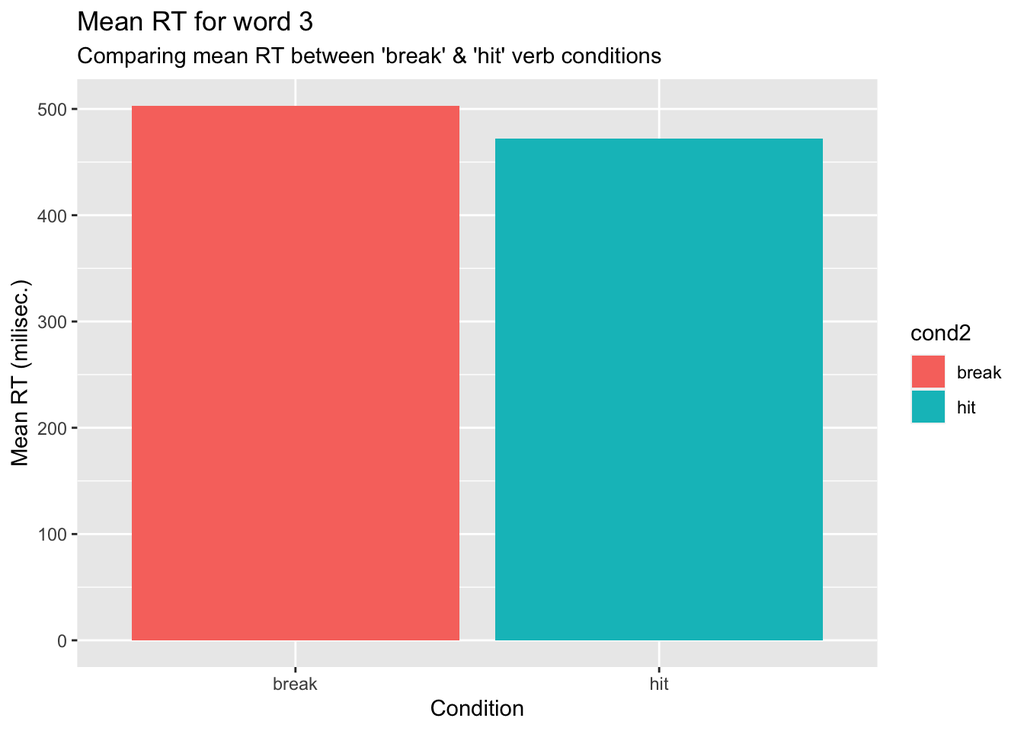

```r
df_kable_mklo %>%
  ggplot(
    aes(
      x=cond2,
      y=mean2
      ))+
  geom_col(aes(fill = cond2))+
  labs(
    title = "Mean RT for word 3",
    subtitle = "Comparing mean RT between 'break' & 'hit' verb conditions",
    y = "Mean RT (milisec.)",
    x = "Condition"
  )
```

Now add words 2 and 4 also. Can you put them in one faceted plot?

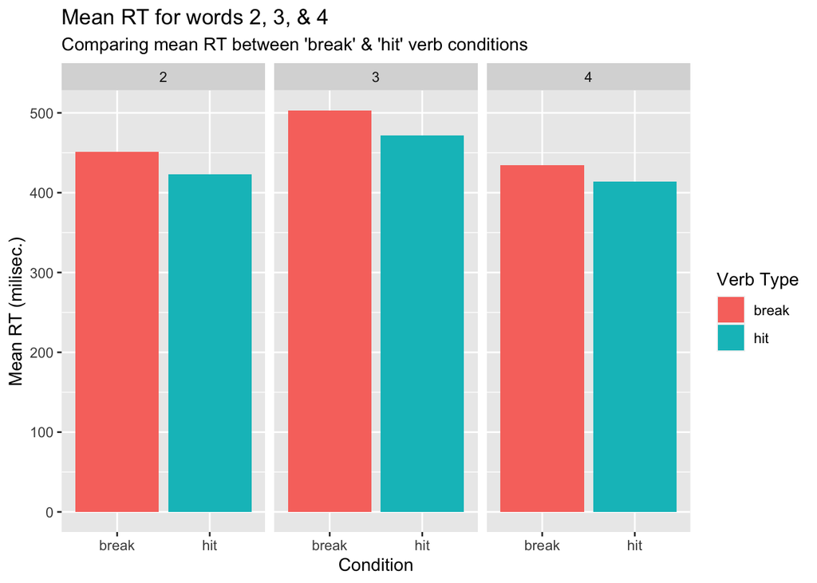

```r
tibble(
  df_sprt_joined %>%
  filter(cond1 == 'mklo' & word_num %in% c('2','3','4')) %>%
  group_by(iphash, cond2, word_num) %>%
  summarize(
    mean = mean(RT, na.rm=TRUE)
  ) %>%
  ungroup() %>%
  group_by(cond2, word_num) %>%
  summarize(
    mean2 = mean(`mean`)
  )
)%>%
  ggplot(
    aes(
      x=cond2,
      y=mean2
      ))+
  geom_col(aes(fill = cond2))+
  facet_wrap(~word_num)+
  labs(
    title = "Mean RT for words 2, 3, & 4",
    subtitle = "Comparing mean RT between 'break' & 'hit' verb conditions",
    y = "Mean RT (milisec.)",
    x = "Condition",
    fill = "Verb Type")
```

# Gennari and Poeppel 2003 Replication

The “gp” stimuli are from the study Gennari and Poeppel 2003. They found that eventive verbs had longer RTs than stative verbs. The verb is the fourth word in these sentences. Was their effect replicated? Try the same steps.

Gennari, S., & Poeppel, D. (2003). Processing correlates of lexical semantic complexity. Cognition, 89(1), B27–B41. https://doi.org/10.1016/S0010-0277(03)00069-6

## Summaries

```r
df_kable_gp <- df_sprt_joined %>%
  filter(cond1 == 'gp' & word_num %in% c('4')) %>%
  group_by(iphash, cond2, word_num) %>%
  summarize(
    mean = mean(RT, na.rm=TRUE)
  ) %>%
  ungroup() %>%
  group_by(cond2) %>%
  summarize(
    mean2 = mean(`mean`)
  )
kableExtra::kbl(df_kable_gp)
```

| cond2 | mean2 |
| --- | --- |
| event | 524.8665 |
| state | 532.6335 |

## Plots

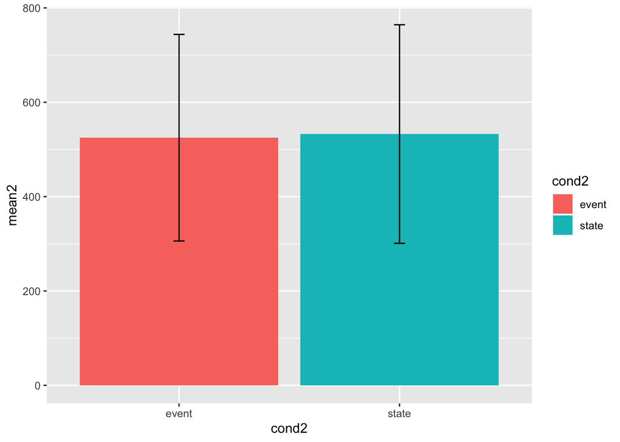

```r
df_sprt_joined %>%
  filter(cond1 == 'gp' & word_num %in% c('4')) %>%
  group_by(iphash, cond2, word_num) %>%
  summarize(
    mean = mean(RT, na.rm=TRUE),
    sd = sd(RT, na.rm=TRUE)
  ) %>%
  ungroup() %>%
  group_by(cond2) %>%
  summarize(
    mean2 = mean(`mean`),
    sd2 = sd(`mean`)
  )%>%
  ggplot(
    aes(
      x = cond2,
      y = mean2
    ))+
  geom_col(aes(fill = cond2))+
  geom_errorbar(aes(ymin=mean2-sd2, ymax=mean2+sd2), width = 0.05, position = position_dodge(.9))
```